# Impact of severe weather events on US population and economy

Ilya Semenov

March 7, 2016

### Synopsis

This is a course project for Coursera/John Hopkins University Reproducible research course. Research based on a storm database provided by U.S. National Oceanic and Atmospheric Administration (NOAA). Main focus of research is the impact of weather events on US population and economy. Based on a data provided by NOAA since 01.03.1950 one can claim that most dangerous for US population weather event is **tornado** whereas most economically harmful events are **floods** and **hurricanes**.

### Data source for analysis

[Source data](https://d396qusza40orc.cloudfront.net/repdata%2Fdata%2FStormData.csv.bz2) for analysis were provided by John Hopkins course staff. Following NOAA documentation was also used:

- National weather service [Storm Data Documentation](https://d396qusza40orc.cloudfront.net/repdata%2Fpeer2_doc%2Fpd01016005curr.pdf)
- National Climatic Data Center Storm Events [FAQ](https://d396qusza40orc.cloudfront.net/repdata%2Fpeer2_doc%2FNCDC%20Storm%20Events-FAQ%20Page.pdf)

## Data loading and preprocessing

Code for loading data frame in R is as follows.

```r
getsets <- function(furl = '') {
    # downloads .zip file from location specified in furl,
    # unzips data and removes downloaded archive from disk
    library(downloader)
    zipfile <- 'StormData.csv.bz2'
    download(fileurl, dest = zipfile, mode = 'wb')
    #unzip(zipfile)
    #unlink(zipfile)
}
fileurl <- 'https://d396qusza40orc.cloudfront.net/repdata%2Fdata%2FStormData.csv.bz2'
if (!file.exists('StormData.csv.bz2')) {
    getsets(fileurl)
}

df <- read.csv('StormData.csv.bz2', stringsAsFactors = FALSE, na = 'NA')
colnames(df)
```

```
##  [1] "STATE__"    "BGN_DATE"   "BGN_TIME"   "TIME_ZONE"  "COUNTY"
##  [6] "COUNTYNAME" "STATE"      "EVTYPE"     "BGN_RANGE"  "BGN_AZI"
## [11] "BGN_LOCATI" "END_DATE"   "END_TIME"   "COUNTY_END" "COUNTYENDN"
## [16] "END_RANGE"  "END_AZI"    "END_LOCATI" "LENGTH"     "WIDTH"
## [21] "F"          "MAG"        "FATALITIES" "INJURIES"   "PROPDMG"
## [26] "PROPDMGEXP" "CROPDMG"    "CROPDMGEXP" "WFO"        "STATEOFFIC"
## [31] "ZONENAMES"  "LATITUDE"   "LONGITUDE"  "LATITUDE_E" "LONGITUDE_"
## [36] "REMARKS"    "REFNUM"
```

We’ll drop columns unnecessary for analysis to save memory and speed up processing.

```r
subdf <- df[,c("EVTYPE","BGN_DATE", "STATE", "FATALITIES","INJURIES","PROPDMG","PROPDMGEXP","CROPDMG","CROPDMGEXP")]
rm(df)
```

Next we’ll convert events dates to R date format.

```r
dates <- as.Date(subdf$BGN_DATE, '%m/%d/%Y %H:%M:%S')
subdf$BGN_DATE <- dates
rm(dates)
```

Original data contain about a thousand different event types.

```r
length(unique(subdf$EVTYPE))
```

```
## [1] 985
```

We need to process events definitions to best meet event types table from NOAA classificator (found at [Storm Data docs](https://d396qusza40orc.cloudfront.net/repdata%2Fpeer2_doc%2Fpd01016005curr.pdf)).

| **Event Name** | **Event Name** |
| --- | --- |
| Astronomical Low Tide | Avalanche |
| Blizzard | Coastal Flood |
| Cold/Wind Chill | Debris Flow |
| Dense Fog | Dense Smoke |
| Drought | Dust Devil |
| Dust Storm | Excessive Heat |
| Extreme Cold/Wind Chill | Flash Flood |
| Flood | Frost/Freeze |
| Funnel Cloud | Freezing Fog |
| Hail | Heat |
| Heavy Rain | Heavy Snow |
| High Surf | High Wind |
| Hurricane (Typhoon) | Ice Storm |
| Lake-Effect Snow | Lakeshore Flood |
| Lightning | Marine Hail |
| Marine High Wind | Marine Strong Wind |
| Rip Current | Marine Thunderstorm Wind |
| Seiche | Sleet |
| Storm Surge/Tide | Strong Wind |
| Thunderstorm Wind | Tornado |
| Tropical Depression | Tropical Storm |
| Tsunami | Volcanic Ash |
| Waterspout | Wildfire |
| Winter Storm | Winter Weather |

Below is the code for events types tidying.

```r
subdf$EVTYPE <- tolower(subdf$EVTYPE)

disasters <- c('Astronomical Low Tide', 'Avalanche', 'Blizzard', 'Coastal Flood', 'Cold',
               'Windhill', 'Debris Flow', 'Dense Fog', 'Dense Smoke', 'Drought', 'Dust Devil',
               'Dust Storm', 'Excessive Heat', 'Extremeold', 'Windhill', 'Flash Flood',
               'Flood', 'Frost', 'Freeze', 'Funnelloud', 'Freezing Fog', 'Hail', 'Heat',
               'Heavy Rain', 'Heavy Snow', 'High Surf', 'High Wind', 'Hurricane', 'Typhoon',
               'Ice Storm', 'Lake-Effect Snow', 'Lakeshore Flood', 'Lightning', 'Marine Hail',
               'Marine High Wind', 'Marine Strong Wind', 'Marine Thunderstorm Wind',
               'Ripurrent', 'Seiche', 'Sleet', 'Storm Surge', 'Tide', 'Strong Wind',
               'Thunderstorm Wind', 'Tornado', 'Tropical Depression', 'Tropical Storm',
               'Tsunami', 'Volcanic Ash', 'Waterspout', 'Wildfire', 'Winter Storm',
               'Winter Weather')
disasters <- tolower(disasters)

for (disaster in disasters) {
    regex <- paste('\\<',disaster, sep = '')
    regex <- paste(regex,'\\>', sep = '')
    ssub <- grepl(pattern = regex, subdf$EVTYPE)
    #exclude marines
    ssub <- ssub & !grepl(pattern = '[Mm]arine', subdf$EVTYPE)
    #exclude excessive for 'heat'
    ssub <- ssub & !grepl(pattern = '[Ee]xcessive', subdf$EVTYPE)
    #exclude flash for 'flood'
    ssub <- ssub & !grepl(pattern = '[Ff]lash', subdf$EVTYPE)
    subdf$EVTYPE[ssub] <- disaster
}

# separate handling for tstm -> tsunami
ssub <- grepl(pattern = 'tstm', subdf$EVTYPE)
subdf$EVTYPE[ssub] <- 'tsunami'

# separate handling for thun* -> thunderstorm wind, exclude marines
ssub <- grepl(pattern = 'thun', subdf$EVTYPE)
ssub <- ssub & !grepl(pattern = '[Mm]arine', subdf$EVTYPE)
subdf$EVTYPE[ssub] <- 'thunderstorm wind'

# separate handling for tunderst* -> thunderstorm winds, exclude marines
ssub <- grepl(pattern = 'tunder', subdf$EVTYPE)
ssub <- ssub & !grepl(pattern = '[Mm]arine', subdf$EVTYPE)
subdf$EVTYPE[ssub] <- 'thunderstorm wind'

# separate handling for torndao/tornados/tornadoes -> tornado
ssub <- grepl(pattern = '(torndao|tornados|tornadoes)', subdf$EVTYPE)
subdf$EVTYPE[ssub] <- 'tornado'

# separate handling for duststorm -> dust storm
ssub <- grepl(pattern = 'duststorm', subdf$EVTYPE)
subdf$EVTYPE[ssub] <- 'dust storm'

# separate handling for high winds -> high wind, exclude marines
ssub <- grepl(pattern = 'high winds', subdf$EVTYPE)
ssub <- ssub & !grepl(pattern = '[Mm]arine', subdf$EVTYPE)
subdf$EVTYPE[ssub] <- 'high wind'

# separate handling for record high -> excessive heat
ssub <- grepl(pattern = 'record high', subdf$EVTYPE)
subdf$EVTYPE[ssub] <- 'excessive heat'

# separate handling for windchill -> wind chill
ssub <- grepl(pattern = 'record high', subdf$EVTYPE)
subdf$EVTYPE[ssub] <- 'excessive heat'

# separate handling for shower -> heavy rain
ssub <- grepl(pattern = 'shower', subdf$EVTYPE)
subdf$EVTYPE[ssub] <- 'heavy rain'

# separate handling for hail* -> hail
ssub <- grepl(pattern = 'hail', subdf$EVTYPE)
subdf$EVTYPE[ssub] <- 'hail'

# separate handling for heavy surf -> high surf
ssub <- grepl(pattern = 'heavy surf', subdf$EVTYPE)
subdf$EVTYPE[ssub] <- 'high surf'

# separate handling for snowfall -> heavy snow
ssub <- grepl(pattern = 'snowfall', subdf$EVTYPE)
subdf$EVTYPE[ssub] <- 'heavy snow'

# separate handling for flash floo* -> flash flooding
ssub <- grepl(pattern = 'flash floo', subdf$EVTYPE)
subdf$EVTYPE[ssub] <- 'flash flood'

# separate handling for *smoke* -> dense smoke
ssub <- grepl(pattern = 'smoke', subdf$EVTYPE)
subdf$EVTYPE[ssub] <- 'dense smoke'

# separate handling for dry*|dri* -> drought
ssub <- grepl(pattern = '(dry|dri)', subdf$EVTYPE)
subdf$EVTYPE[ssub] <- 'drought'

# separate handling for rainfall -> heavy rain
regex <- paste('\\<', 'rainfall', sep = '')
regex <- paste(regex,'\\>', sep = '')
ssub <- grepl(pattern = regex, subdf$EVTYPE)
subdf$EVTYPE[ssub] <- 'heavy rain'

# separate handling for rain -> heavy rain
regex <- paste('\\<', 'rain', sep = '')
regex <- paste(regex,'\\>', sep = '')
ssub <- grepl(pattern = regex, subdf$EVTYPE)
subdf$EVTYPE[ssub] <- 'heavy rain'

# separate handling for hot/warm -> heat
regex <- paste('\\<', '(hot|warm)', sep = '')
regex <- paste(regex,'\\>', sep = '')
ssub <- grepl(pattern = regex, subdf$EVTYPE)
subdf$EVTYPE[ssub] <- 'heat'

# separate handling for snow -> heavy snow
regex <- paste('\\<', 'snow', sep = '')
regex <- paste(regex,'\\>', sep = '')
ssub <- grepl(pattern = regex, subdf$EVTYPE)
subdf$EVTYPE[ssub] <- 'heavy snow'

#assign typhoon to hurricane and then hurricane to 'hurricane (typhoon)'
ssub <- grepl(pattern = 'typhoon', subdf$EVTYPE)
subdf$EVTYPE[ssub] <- 'hurricane'
ssub <- grepl(pattern = 'hurricane', subdf$EVTYPE)
subdf$EVTYPE[ssub] <- 'hurricane (typhoon)'

#assign tide to storm surge and then storm surge to 'storm surge/tide', exclude astronomical low tides
ssub <- grepl(pattern = 'tide', subdf$EVTYPE)
ssub <- ssub & !grepl(pattern = '[Aa]stronom', subdf$EVTYPE)
subdf$EVTYPE[ssub] <- 'storm surge'
ssub <- grepl(pattern = 'storm surge', subdf$EVTYPE)
subdf$EVTYPE[ssub] <- 'storm surge/tide'

#assign freeze to frost and then frost to 'frost/freeze'
ssub <- grepl(pattern = 'freeze', subdf$EVTYPE)
subdf$EVTYPE[ssub] <- 'frost'
ssub <- grepl(pattern = 'frost', subdf$EVTYPE)
subdf$EVTYPE[ssub] <- 'frost/freeze'

#assign wind chill to cold and then cold to 'cold/wind chill'
ssub <- grepl(pattern = 'wind chill', subdf$EVTYPE)
subdf$EVTYPE[ssub] <- 'cold'
ssub <- grepl(pattern = 'cold', subdf$EVTYPE)
subdf$EVTYPE[ssub] <- 'cold/wind chill'


disasters <- append(disasters,
                    c('cold/wind chill', 'frost/freeze',
                      'storm surge/tide', 'hurricane (typhoon)'))
```

Next we’ll collapse the events descriptions that doesn’t quite good match with NOAA approved event types to ‘others’.

```r
ssub <- subdf$EVTYPE %in% disasters
subdf$EVTYPE[!ssub] <- 'other'
```

Last check for the fact that our event description tidying is more or less correct:

```r
unique(subdf$EVTYPE)
```

```
##  [1] "tornado"                  "tsunami"
##  [3] "hail"                     "heavy rain"
##  [5] "heavy snow"               "flash flood"
##  [7] "winter storm"             "hurricane (typhoon)"
##  [9] "thunderstorm wind"        "cold/wind chill"
## [11] "lightning"                "dense fog"
## [13] "other"                    "high wind"
## [15] "heat"                     "flood"
## [17] "waterspout"               "blizzard"
## [19] "frost/freeze"             "storm surge/tide"
## [21] "excessive heat"           "ice storm"
## [23] "avalanche"                "dust storm"
## [25] "sleet"                    "dust devil"
## [27] "high surf"                "drought"
## [29] "strong wind"              "winter weather"
## [31] "tropical storm"           "wildfire"
## [33] "freezing fog"             "volcanic ash"
## [35] "seiche"                   "tropical depression"
## [37] "dense smoke"              "marine high wind"
## [39] "marine thunderstorm wind" "marine strong wind"
```

## Weather events fatalities analysis

First, let have a look on fatalities record.

```r
fatalities <- aggregate(subdf$FATALITIES, by = list(subdf$EVTYPE), FUN = sum)
shrFatalities <- sum(fatalities$x) / 100
fatalities$share <- fatalities$x / shrFatalities
fatalities[order(-fatalities$x),][c(1:15),]
```

```
##              Group.1    x      share
## 32           tornado 5636 37.2136018
## 9     excessive heat 1903 12.5652030
## 15              heat 1223  8.0752724
## 10       flash flood 1035  6.8339386
## 26             other  899  5.9359525
## 22         lightning  817  5.3945196
## 35           tsunami  547  3.6117531
## 11             flood  477  3.1495543
## 3    cold/wind chill  451  2.9778805
## 19         high wind  293  1.9346319
## 1          avalanche  224  1.4790360
## 39      winter storm  207  1.3667877
## 31 thunderstorm wind  202  1.3337735
## 18         high surf  162  1.0696600
## 17        heavy snow  145  0.9574117
```

Next, let have a look on injuries.

```r
injuries <- aggregate(subdf$INJURIES, by = list(subdf$EVTYPE), FUN = sum)
shrInjuries <- sum(injuries$x) / 100
injuries$share <- injuries$x / shrInjuries
injuries[order(-injuries$x),][c(1:15),]
```

```
##                Group.1     x      share
## 32             tornado 91407 65.0454002
## 35             tsunami  7099  5.0516623
## 11               flood  6793  4.8339121
## 9       excessive heat  6525  4.6432028
## 22           lightning  5232  3.7231014
## 26               other  2802  1.9939087
## 15                heat  2703  1.9234601
## 31   thunderstorm wind  2452  1.7448480
## 21           ice storm  1990  1.4160879
## 10         flash flood  1802  1.2823067
## 19           high wind  1502  1.0688261
## 14                hail  1467  1.0439201
## 39        winter storm  1336  0.9507002
## 20 hurricane (typhoon)  1333  0.9485654
## 17          heavy snow  1120  0.7969942
```

This time tornadoes are outstanding, that is somewhat expectable in view of devastating nature of this type of an event. Also one can note relatively low rate of tornado’s dead/injured rate. Let combine together fatalities and injuries data and barplot them together.

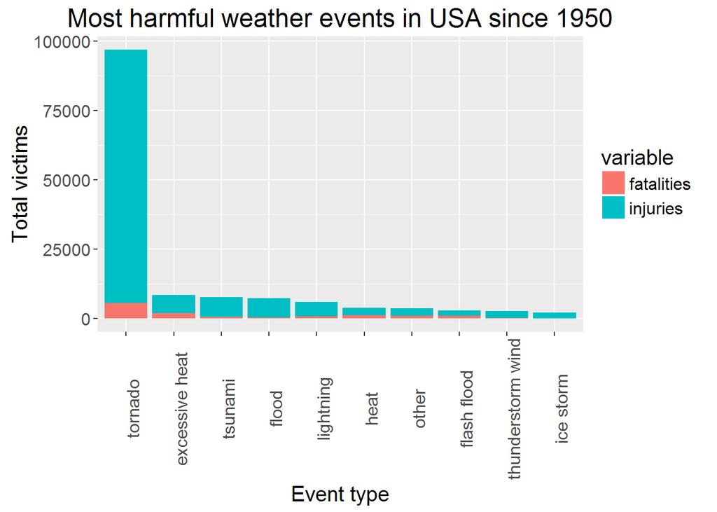

```r
library(ggplot2)
library(data.table)
setnames(fatalities, old=c("x", "Group.1"), new=c("fatalities", "event_type"))
setnames(injuries, old=c("x", "Group.1"), new=c("injuries", "event_type"))
victims <- merge(fatalities, injuries, by="event_type")
victims$total <- victims$fatalities + victims$injuries
victimsTop <- victims[order(-victims$total),][c(1:10),]
victimsTopMelt <- melt(victimsTop, id.vars=c("event_type"),
                       measure.vars=c("fatalities", "injuries"))

ggplot(data=victimsTopMelt,
       aes(x=reorder(victimsTopMelt$event_type, -victimsTopMelt$value),
           y=victimsTopMelt$value, fill=variable)) +
    geom_bar(stat="identity") +
    theme(axis.text.x=element_text(angle=90)) +
    ylab("Total victims") +
    xlab("Event type") +
    theme(text = element_text(size = 15)) +
    ggtitle("Most harmful weather events in USA since 1950")
```

## Weather events economy losses analysis

### Exponential numeric format processing

Database contains two basic types of economy losses: properties damage and crops damage. Each losses type amount is split in two different columns: one for mantissa and one for exponent. Preprocessing task is to decrypt exponent column data.

```r
table(subdf$PROPDMGEXP)
```

```
##
##             -      ?      +      0      1      2      3      4      5
## 465934      1      8      5    216     25     13      4      4     28
##      6      7      8      B      h      H      K      m      M
##      4      5      1     40      1      6 424665      7  11330
```

```r
table(subdf$CROPDMGEXP)
```

```
##
##             ?      0      2      B      k      K      m      M
## 618413      7     19      1      9     21 281832      1   1994
```

```r
procexp <- function(x){
    switch (tolower(x),
            h = return(2),
            k = return(3),
            m = return(6),
            b = return(9)
    )
    is.numeric <- suppressWarnings(!is.na(as.numeric(x)))
    return(if (is.numeric) as.numeric(x) else 0)
}
subdf$propnumexp <- sapply(as.character(subdf$PROPDMGEXP), FUN = procexp)
table(subdf$propnumexp)
```

```
##
##      0      1      2      3      4      5      6      7      8      9
## 466164     25     20 424669      4     28  11341      5      1     40
```

```r
subdf$cropnumexp <- sapply(as.character(subdf$CROPDMGEXP), FUN = procexp)
table(subdf$cropnumexp)
```

```
##
##      0      2      3      6      9
## 618439      1 281853   1995      9
```

### Economy losses analysis

Let take a look on properties damage.

```r
propdamage <- aggregate(subdf$PROPDMG * 10^subdf$propnumexp,
                        by = list(subdf$EVTYPE), FUN = sum)
shrPropdamage <- sum(propdamage$x) / 100
propdamage$share <- propdamage$x / shrPropdamage
propdamage[order(-propdamage$x),][c(1:15),]
```

```
##                Group.1            x      share
## 11               flood 150202157117 35.0755335
## 20 hurricane (typhoon)  85356410010 19.9326140
## 32             tornado  57003318377 13.3115385
## 29    storm surge/tide  47974469150 11.2031021
## 14                hail  17622951537  4.1153499
## 10         flash flood  17588292096  4.1072561
## 34      tropical storm   7714390550  1.8014812
## 39        winter storm   6748497251  1.5759237
## 31   thunderstorm wind   6640254781  1.5506467
## 19           high wind   5887848043  1.3749430
## 38            wildfire   4765114000  1.1127598
## 35             tsunami   4643174995  1.0842843
## 26               other   4610000610  1.0765373
## 21           ice storm   3946027860  0.9214850
## 16          heavy rain   3229773642  0.7542237
```

Floods are definite leaders, next are hurricanes and tornadoes.

Now let look on crops damages.

```r
cropdamage <- aggregate(subdf$CROPDMG * 10^subdf$cropnumexp,
                        by = list(subdf$EVTYPE), FUN = sum)
shrCropdamage <- sum(cropdamage$x) / 100
cropdamage$share <- cropdamage$x / shrCropdamage
cropdamage[order(-cropdamage$x),][c(1:15),]
```

```
##                Group.1           x      share
## 6              drought 13972631000 28.4550674
## 11               flood 10805205950 22.0046507
## 20 hurricane (typhoon)  5516117800 11.2334967
## 21           ice storm  5022113500 10.2274638
## 14                hail  3114212873  6.3420509
## 13        frost/freeze  1997061000  4.0669868
## 10         flash flood  1532197150  3.1202980
## 3      cold/wind chill  1416765550  2.8852232
## 16          heavy rain   745652800  1.5185115
## 34      tropical storm   694896000  1.4151460
## 19           high wind   679301900  1.3833888
## 31   thunderstorm wind   652791388  1.3294005
## 35             tsunami   554027350  1.1282689
## 9       excessive heat   492402000  1.0027698
## 32             tornado   414961470  0.8450632
```

Droughts have the most devastating effect on crops. Also one can note that crops damage is less than an order of magnitude lower than properties damage.

Now let plot properties and crops damages together.

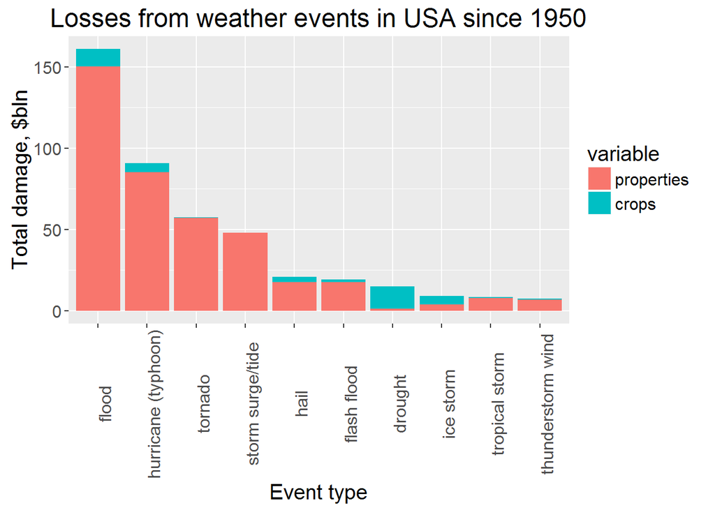

```r
setnames(propdamage, old=c("x", "Group.1"), new=c("properties", "event_type"))
setnames(cropdamage, old=c("x", "Group.1"), new=c("crops", "event_type"))
damages <- merge(propdamage, cropdamage, by="event_type")
damages$total <- damages$properties + damages$crops
damagesTop <- damages[order(-damages$total),][c(1:10),]
damagesTopMelt <- melt(damagesTop, id.vars=c("event_type"),
                       measure.vars=c("properties", "crops"))

ggplot(data=damagesTopMelt,
       aes(x=reorder(damagesTopMelt$event_type, -damagesTopMelt$value),
           y=damagesTopMelt$value / 10^9, fill=variable)) +
    geom_bar(stat="identity") +
    theme(axis.text.x=element_text(angle=90)) +
    ylab("Total damage, $bln") +
    xlab("Event type") +
    theme(text = element_text(size = 15)) +
    ggtitle("Losses from weather events in USA since 1950")
```

## Results

#### Population impact

Tornadoes appear to be most harmful weather event for US public health according to NOAA database. They are responsible for more than 37% of total registered deaths from weather events and for more than 65% injuries. Average annual death rate from tornado is about 92 people a year.

Total average death rate from weather events is about 250 people a year that is relatively low compared to, for example, annual death rate from airplane crashes in US that is slightly lower than 1000 people a year ([source](http://www.planecrashinfo.com/cause.htm)). So one must be aware of the dangerous weather events but should not overestimate the threat.

#### Economy impact

Most dangerous weather events from losses for properties point of view are floods, hurricanes and tornadoes. They are responsible for almost 70% of total property losses from weather events. Annual loss rate for properties from those top 3 weather events is about $4,8 bln.

Crops damage from weather events has less devastating effect. Most dangerous events from agricultural point of view are droughts, floods and hurricanes. Those top 3 are responsible for about 62% total crops losses. Annual economic loss for crops from those events is about $500 mln a year.